# Research project

Oleksii Lasiichuk, Denys Marchenko, Marko Pasternak

# Probability and Statistics

# Research project: Statistical analysys of chess games

## Short desription

This research project utilizes a dataset of chess games played on the Lichess platform to investigate statistical patterns in online play. Our analysis focuses on two primary objectives: first, to determine if the classification of an opening (Open, Closed, Semi-Open, Semi-Closed, or Flank) significantly influences the duration of a game; and second, to evaluate the predictive power of rating differentials in determining match outcomes.

# 0. Data Preprocessing

The [dataset](https://www.kaggle.com/datasets/datasnaek/chess) utilized in this study comprises approximately 20,000 chess games played online on the Lichess platform. The raw dataset contains the following variables:

- **Game ID:** Unique identifier for the match.
- **Rated (T/F):** Boolean indicating if the match affects player ratings.
- **Start Time / End Time:** Timestamp of the game.
- **Number of Turns:** Total moves played.
- **Game Status:** Result condition (e.g., resign, mate, draw).
- **Winner:** White, Black, or Draw.
- **Time Increment:** Time control settings.
- **White/Black Player ID:** Usernames of the players.
- **White/Black Player Rating:** ELO rating of the players.
- **Moves:** Full move history in standard chess notation.
- **Opening Eco:** Standardized Encyclopedia of Chess Openings code.
- **Opening Name:** The traditional name of the opening.
- **Opening Ply:** Number of moves in the opening phase.

### Feature Selection and Engineering

To facilitate our specific research aims, we performed data cleaning and feature engineering.

First, we removed metadata columns that are unimportant to our statistical analysis of game mechanics. Specifically, **Game ID**, **Start Time**, **End Time**, **White Player ID**, and **Black Player ID** were excluded.

Second, we removed all unrated games. Since these matches are typically used for training or casual play, they were treated as non-representative outliers to prevent skewing the results.

Third, we engineered several new variables to categorize the data for hypothesis testing:

1. **Opening Type:** A categorical variable classifying the opening into one of five standard chess systems: *Open*, *Closed*, *Semi-Open*, *Semi-Closed*, or *Flank*.
2. **Average Rating:** The mean rating of the two players `(White Rating + Black Rating) / 2`, used to gauge the overall skill level of the match.
3. **Rating Gap:** The absolute difference in rating between the two players (`abs(White Rating - Black Rating)`).
4. **Outcome:** A categorical variable describing the result relative to rating expectations:
   - *Expected Win:* The higher-rated player won.
   - *Upset:* The lower-rated player won.
   - *Draw:* The game ended in a draw.
   - *Even:* Both players have the same rating.
5. **Gap Category:** A binned version of the Rating Gap variable (e.g., 0–50, 50–100, 100–150) to allow for grouped analysis of rating disparities.

```r
library(dplyr)
```

```r
library(stringr)

# Load data
chess_data <- read.csv("games.csv")

clean_data <- chess_data %>%
  # 1. Filter for RATED games only
  filter(rated == TRUE) %>%

  # 2. Feature Selection (Remove columns)
  select(-id, -created_at, -last_move_at, -white_id, -black_id, -rated) %>%

  # 2. Feature Engineering
  mutate(
    # Average Rating
    average_rating = (white_rating + black_rating) / 2,

    # Rating Gap (Absolute difference)
    rating_gap = abs(white_rating - black_rating),

    # Opening Type
    opening_first_two = word(moves, 1, 2), # Extract first two moves
    opening_type = case_when(
      opening_first_two == "e4 e5" ~ "Open Game",
      str_detect(opening_first_two, "^e4") & opening_first_two != "e4 e5" ~ "Semi-Open Game",
      opening_first_two == "d4 d5" ~ "Closed Game",
      str_detect(opening_first_two, "^d4") & opening_first_two != "d4 d5" ~ "Semi-Closed Game",
      TRUE ~ "Flank Opening"
    ),

    # Outcome (Expected vs Upset)
    outcome_type = case_when(
      winner == "draw" ~ "Draw",
      (winner == "white" & white_rating > black_rating) ~ "Expected Win",
      (winner == "black" & black_rating > white_rating) ~ "Expected Win",
      TRUE ~ "Upset"
    ),

    # Gap Category (Binning the gap)
    gap_category = cut(rating_gap,
                       breaks = seq(0, max(rating_gap)+50, by = 50),
                       include.lowest = TRUE)
  )


head(clean_data)
```

|  | turns | victory_status | winner | increment_code | white_rating | black_rating | moves | opening_eco | opening_name | opening_ply | average_rating | rating_gap | opening_first_two | opening_type | outcome_type | gap_category |
| --- | --- | --- | --- | --- | --- | --- | --- | --- | --- | --- | --- | --- | --- | --- | --- | --- |
| 1 | 16 | resign | black | 5+10 | 1322 | 1261 | d4 Nc6 e4 e5 f4 f6 dxe5 fxe5 fxe5 Nxe5 Qd4 Nc6 Qe5+ Nxe5 c4 Bb4+ | B00 | Nimzowitsch Defense: Kennedy Variation | 4 | 1291.5 | 61 | d4 Nc6 | Semi-Closed Game | Upset | (50,100] |
| 2 | 61 | mate | white | 5+10 | 1496 | 1500 | e4 e5 d3 d6 Be3 c6 Be2 b5 Nd2 a5 a4 c5 axb5 Nc6 bxc6 Ra6 Nc4 a4 c3 a3 Nxa3 Rxa3 Rxa3 c4 dxc4 d5 cxd5 Qxd5 exd5 Be6 Ra8+ Ke7 Bc5+ Kf6 Bxf8 Kg6 Bxg7 Kxg7 dxe6 Kh6 exf7 Nf6 Rxh8 Nh5 Bxh5 Kg5 Rxh7 Kf5 Qf3… | C20 | King's Pawn Game: Leonardis Variation | 3 | 1498.0 | 4 | e4 e5 | Open Game | Upset | [0,50] |
| 3 | 61 | mate | white | 20+0 | 1439 | 1454 | d4 d5 Nf3 Bf5 Nc3 Nf6 Bf4 Ng4 e3 Nc6 Be2 Qd7 O-O O-O-O Nb5 Nb4 Rc1 Nxa2 Ra1 Nb4 Nxa7+ Kb8 Nb5 Bxc2 Bxc7+ Kc8 Qd2 Qc6 Na7+ Kd7 Nxc6 bxc6 Bxd8 Kxd8 Qxb4 e5 Qb8+ Ke7 dxe5 Be4 Ra7+ Ke6 Qe8+ Kf5 Qxf7+ Nf6 … | D02 | Queen's Pawn Game: Zukertort Variation | 3 | 1446.5 | 15 | d4 d5 | Closed Game | Upset | [0,50] |
| 4 | 95 | mate | white | 30+3 | 1523 | 1469 | e4 e5 Nf3 d6 d4 Nc6 d5 Nb4 a3 Na6 Nc3 Be7 b4 Nf6 Bg5 O-O b5 Nc5 Bxf6 Bxf6 Bd3 Qd7 O-O Nxd3 Qxd3 c6 a4 cxd5 Nxd5 Qe6 Nc7 Qg4 Nxa8 Bd7 Nc7 Rc8 Nd5 Qg6 Nxf6+ Qxf6 Rfd1 Re8 Qxd6 Bg4 Qxf6 gxf6 Rd3 Bxf3 Rxf… | C41 | Philidor Defense | 5 | 1496.0 | 54 | e4 e5 | Open Game | Expected Win | (50,100] |
| 5 | 33 | resign | white | 10+0 | 1520 | 1423 | d4 d5 e4 dxe4 Nc3 Nf6 f3 exf3 Nxf3 Nc6 Bb5 a6 Bd3 Bg4 O-O Nxd4 Be2 Nxe2+ Qxe2 Bxf3 Qxf3 Qd4+ Be3 Qg4 Qxb7 Rd8 Qc6+ Nd7 Nd5 e6 Nxc7+ Ke7 Bd2 | D00 | Blackmar-Diemer Gambit: Pietrowsky Defense | 10 | 1471.5 | 97 | d4 d5 | Closed Game | Expected Win | (50,100] |
| 6 | 66 | resign | black | 15+0 | 1439 | 1392 | e4 e5 Bc4 Nc6 Nf3 Nd4 d3 Nxf3+ Qxf3 Nf6 h3 Bc5 a3 O-O Be3 Bxe3 Qxe3 Re8 Qf3 c6 Nc3 b5 Bb3 Qa5 O-O Bb7 Ne2 c5 Rfd1 d6 c4 bxc4 dxc4 Rac8 Rd5 Bxd5 exd5 Qb6 Nc1 e4 Qf4 Nh5 Qg4 Nf6 Qf4 Qa5 Bc2 Qe1+ Kh2 Nh5… | C50 | Italian Game: Schilling-Kostic Gambit | 6 | 1415.5 | 47 | e4 e5 | Open Game | Upset | [0,50] |

# 1. The Impact of Opening Type on Game Duration

### Classification of Chess Openings

The opening phase is critical in determining the trajectory and character of a chess game. We categorize games into five distinct types based on the initial move order:

- **Open Games (**$1. e4\ e5$): Characterized by immediate interaction in the center. These positions often lead to open lines for piece activity, favoring tactical and dynamic play.
- **Closed Games (**$1. d4\ d5$): Characterized by a stabilized center. These games often evolve into slower, strategic battles where maneuvering on the queenside is more common than direct attacks on the king.
- **Semi-Open Games (**$1. e4$, black responds $\neq e5$): Black allows White to occupy the center to attack it later. This creates immediate structural imbalances, often resulting in sharp, counter-attacking games (e.g., the Sicilian Defense).
- **Semi-Closed Games (**$1. d4$, black responds $\neq d5$): Black responds asymmetrically to $d4$. These systems lead to complex strategic imbalances where predicting the flow is difficult.
- **Flank Openings (White moves** $\neq e4, d4$): White attacks the center from the sides (e.g., $1. c4$ or $1. Nf3$). These are highly flexible and hard to generalize.

*Note:* While these classifications describe statistical tendencies, they are not deterministic. Open games can transpose into quiet positions, and Closed games can become tactically volatile.

### Hypothesis Formulation

We aim to test whether the chosen opening category has a statistically significant effect on the duration of the game (measured in number of moves).

Let $D$ be the random variable representing the duration of a game. We define the median duration for each opening type as follows:

- $\theta_{open}$: Median moves for Open games
- $\theta_{closed}$: Median moves for Closed games
- $\theta_{semi\_open}$: Median moves for Semi-Open games
- $\theta_{semi\_closed}$: Median moves for Semi-Closed games
- $\theta_{flank}$: Median moves for Flank games

**Null Hypothesis (**$H_0$): The type of opening has no effect on game duration. The median game lengths are equal across all categories.
$$H_0: \theta_{open} =
\theta_{closed} = \theta_{semi\_open} = \theta_{semi\_closed} =
\theta_{flank}$$

**Alternative Hypothesis (**$H_1$): The opening type influences the game duration. At least one group’s median differs from the others.
$$H_1: \exists (i, j) \text{ such that }
\theta_i \neq \theta_j$$

**Theoretical Prediction:** Based on the tactical nature of **Open Games**, we predict $\theta_{open}$ will be the lowest, as tactical errors often lead to quick decisive results (checkmate or resignation). Conversely, we predict $\theta_{closed}$ will be the highest, as these games rely on long-term positional maneuvering where decisive advantages take longer to accumulate.

### Methodology

To test these hypotheses, we will utilize the **Kruskal-Wallis Rank Sum Test**.

This non-parametric test is expedient for our analysis because:

1. **Non-Normality:** We anticipate that the distribution of chess game lengths will be right-skewed and non-normal. This would violate the normality assumption required for a standard **ANOVA** (Analysis of Variance), which is the traditional parametric test used to compare the means of three or more groups. We will verify this distribution visually in the Descriptive Analysis section.
2. **Multiple Groups:** We are comparing five distinct independent groups. As the **Mann-Whitney U test** is limited to comparing the distributions of only *two* groups, the Kruskal-Wallis test serves as the necessary extension to handle our multi-group comparison simultaneously.

If the Kruskal-Wallis test indicates significance ($p < 0.05$), we will reject $H_0$ and conclude that opening choice does impact game longevity.

### Descriptive analysis of data

```r
library(ggplot2)
library(dplyr)
library(knitr)

# --- 1. Summary Statistics Table (Unchanged) ---
desc_stats <- clean_data %>%
  group_by(opening_type) %>%
  summarise(
    Count = n(),
    Mean_Turns = mean(turns, na.rm = TRUE),
    Median_Turns = median(turns, na.rm = TRUE),
    SD_Turns = sd(turns, na.rm = TRUE),
    Min = min(turns, na.rm = TRUE),
    Max = max(turns, na.rm = TRUE)
  ) %>%
  arrange(desc(Median_Turns))

kable(desc_stats, caption = "Summary Statistics of Game Duration by Opening Type")
```

Summary Statistics of Game Duration by Opening Type

| opening_type | Count | Mean_Turns | Median_Turns | SD_Turns | Min | Max |
| --- | --- | --- | --- | --- | --- | --- |
| Semi-Closed Game | 839 | 64.65197 | 58 | 32.59739 | 2 | 204 |
| Closed Game | 832 | 63.34615 | 57 | 33.62478 | 2 | 208 |
| Semi-Open Game | 2513 | 62.04815 | 57 | 32.86592 | 2 | 255 |
| Flank Opening | 1054 | 59.71822 | 55 | 32.92634 | 1 | 188 |
| Open Game | 2194 | 58.56199 | 53 | 33.03090 | 2 | 221 |

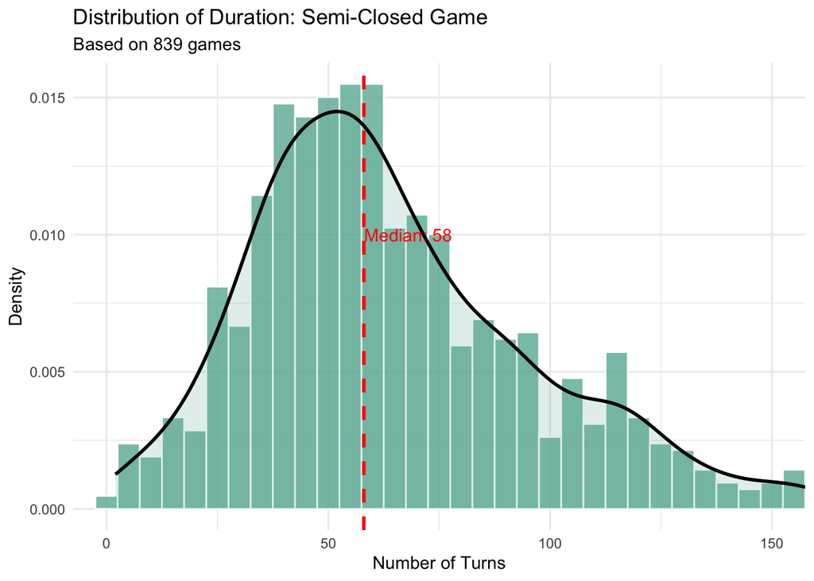

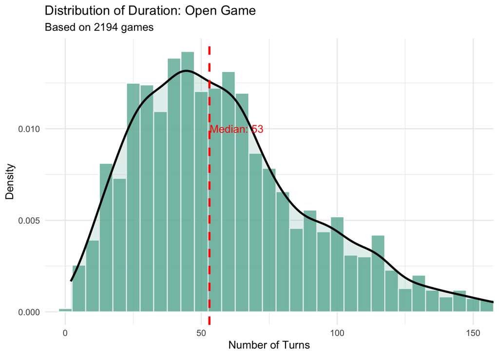

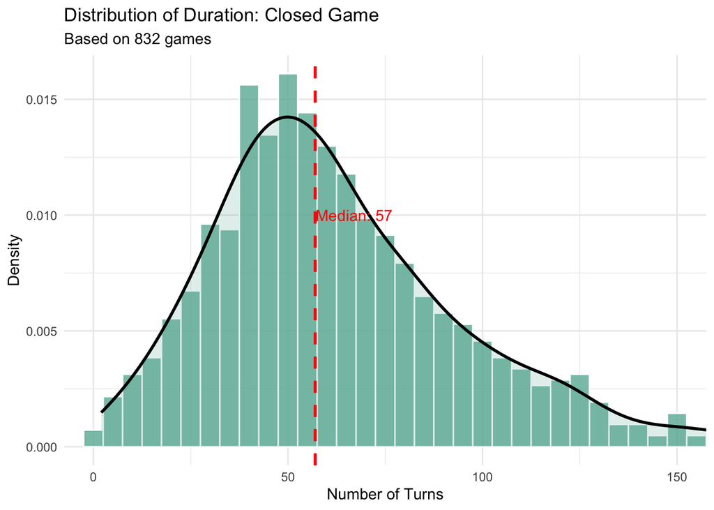

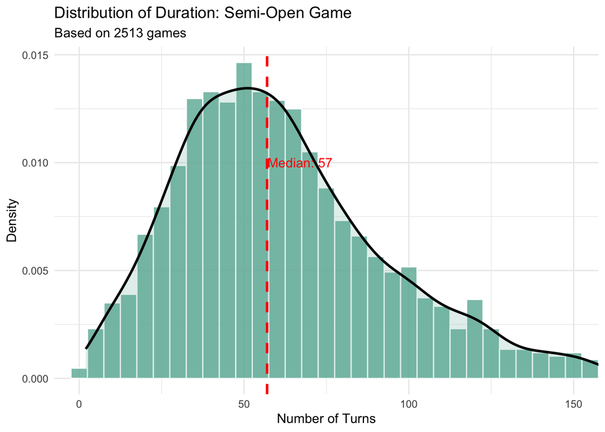

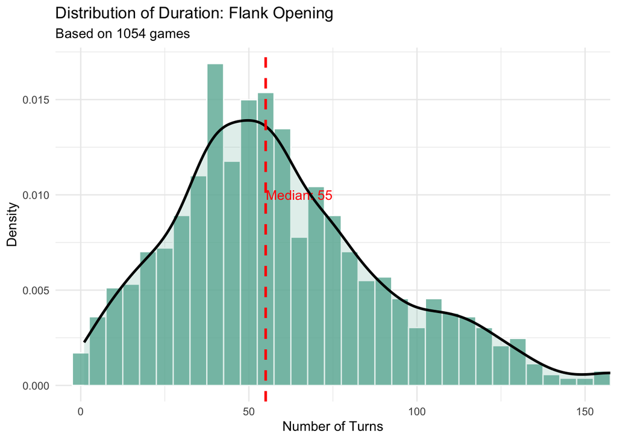

```r
# --- 2. Individual Histograms Loop ---
# We get a list of all unique opening types
types <- unique(clean_data$opening_type)

# We loop through each type to create a separate graph
for (type in types) {

  # Filter data for just this one opening type
  subset_data <- clean_data %>% filter(opening_type == type)

  # Calculate the median for this specific group to draw a vertical line
  this_median <- median(subset_data$turns, na.rm = TRUE)

  # Create the plot
  p <- ggplot(subset_data, aes(x = turns)) +
    geom_histogram(aes(y = after_stat(density)), binwidth = 5, fill = "#69b3a2", color = "white", alpha = 0.8) +
    geom_density(alpha = 0.2, fill = "#69b3a2", linewidth = 1) +

    # Add a vertical red line for the Median
    geom_vline(aes(xintercept = this_median), color = "red", linetype = "dashed", linewidth = 1) +

    # Add a text label for the median value
    annotate("text", x = this_median + 10, y = 0.01, label = paste("Median:", this_median), color = "red") +

    labs(
      title = paste("Distribution of Duration:", type),
      subtitle = paste("Based on", nrow(subset_data), "games"),
      x = "Number of Turns",
      y = "Density"
    ) +
    theme_minimal() +
    coord_cartesian(xlim = c(0, 150))

  # In R loops, you must explicitly call print() to show the graph
  print(p)
}
```

**3. The “Strategic Cluster”:** Interestingly, the data contradicts the assumption that Closed games are uniquely long. Instead, we observe a “strategic cluster”: **Closed (57), Semi-Open (57), and Semi-Closed (58)** games all share a nearly identical median duration. This suggests that any deviation from the open $1. e4\ e5$ structure—whether through $d4$ or asymmetric defenses—tends to extend the game by an average of 4-5 moves.

**4. Flank Openings:** Flank openings occupy a transitional middle ground with a median of **55 moves**. While visual inspection suggests a distinct distribution profile, statistical analysis shows their volatility (Standard Deviation $\approx 33$) is consistent with all other opening types. This indicates that high variance in game length is an inherent property of chess itself, rather than a specific feature of Flank systems.

To characterize the nature of these openings beyond simple duration, we examine three additional statistics:

- **Interquartile Range (IQR):** Measures the spread of the middle 50% of the data. In this context, IQR serves as a proxy for **consistency**; a higher value indicates unpredictable, volatile game lengths.
- **Miniature Rate (**$< 25$ moves): Measures the percentage of games ending quickly. This serves as a metric for **sharpness**, identifying openings that lead to immediate tactical decisiveness.
- **Draw Rate:** Measures the percentage of games ending in a draw. This correlates with **strategic stability**, as solid positions are harder to break down and often extend into long endgames.

```r
# Extended Descriptive Statistics Table
extended_stats <- clean_data %>%
  group_by(opening_type) %>%
  summarise(
    Median = median(turns),
    IQR = IQR(turns),
    Miniature_Rate = paste0(round(mean(turns < 25) * 100, 1), "%"),
    Draw_Rate = paste0(round(mean(winner == "draw") * 100, 1), "%")
  ) %>%
  arrange(desc(Median))

kable(extended_stats, caption = "Volatility and Character Metrics by Opening Type")
```

Volatility and Character Metrics by Opening Type

| opening_type | Median | IQR | Miniature_Rate | Draw_Rate |
| --- | --- | --- | --- | --- |
| Semi-Closed Game | 58 | 42 | 6.8% | 5.1% |
| Closed Game | 57 | 41 | 9.3% | 4.7% |
| Semi-Open Game | 57 | 41 | 9.9% | 4.4% |
| Flank Opening | 55 | 40 | 13% | 3.5% |
| Open Game | 53 | 43 | 13.6% | 4% |

Beyond the median duration, the supplementary metrics reveal distinct behavioral profiles for each opening category:

**1. The “Sharpness” of Open Games:** The **Miniature Rate** (< 25 moves) provides the strongest evidence for our hypothesis regarding the volatility of Open Games. At **13.6%**, the probability of an Open Game ending in the opening phase is **exactly double** that of a Semi-Closed Game (6.8%). This statistically confirms that $1. e4\ e5$ positions carry a significantly higher risk of immediate tactical decisiveness compared to $1. d4$ systems.

**2. The Unexpected Decisiveness of Flank Openings:** Contrary to the common belief that Flank openings are passive, the data shows they are highly decisive. They possess the **lowest draw rate (3.5%)** of all categories and a **Miniature Rate (13%)** nearly identical to Open Games. This suggests that while Flank openings (like the English or Reti) are positionally complex, they create imbalances that force a result—win or loss—rather than leading to safe, sterile draws.

**3. Stability of Variance (IQR):** The **Interquartile Range (IQR)** is remarkably consistent across all groups, ranging tightly between **40 and 43 moves**. This is a crucial negative finding: it indicates that while the *median* length shifts depending on the opening, the *unpredictability* (spread) of the game length is an inherent property of chess itself, rather than a feature of any specific opening system.

**4. Strategic Solidity:** The **Semi-Closed** and **Closed** games exhibit the highest draw rates (5.1% and 4.7%) and the lowest miniature rates. This inverse relationship—low risk of quick loss combined with higher draw probability—statistically defines these openings as the most “solid” choices for risk-averse players.

**Conclusion & Next Steps:** We have visually identified a likely difference between **Open Games** and the **Rest**. The next step is to perform the Kruskal-Wallis test to determine if these observed differences (53 vs. 58) are statistically significant or merely due to random variance.

```r
# Load necessary libraries
library(broom) # For tidying statistical outputs
library(knitr) # For nice tables

# --- 1. The Global Test (Kruskal-Wallis) ---
# This checks if at least one group is different from the others
kw_result <- kruskal.test(turns ~ opening_type, data = clean_data)

print(kw_result)
```

```
##
##  Kruskal-Wallis rank sum test
##
## data:  turns by opening_type
## Kruskal-Wallis chi-squared = 36.942, df = 4, p-value = 1.852e-07
```

```r
# --- 2. Interpretation & Post-Hoc Analysis ---
# We only run step 2 if the p-value is significant (< 0.05)
if(kw_result$p.value < 0.05) {

  # Pairwise Wilcoxon Test with Bonferroni correction
  # This compares every opening against every other opening
  pairwise_result <- pairwise.wilcox.test(clean_data$turns,
                                          clean_data$opening_type,
                                          p.adjust.method = "bonferroni")

  # Display the matrix of p-values
  # Values < 0.05 indicate a statistically significant difference between those two specific groups

  print(pairwise_result)

} else {
  print("Result: No significant difference found. We cannot reject the Null Hypothesis.")
}
```

```
##
##  Pairwise comparisons using Wilcoxon rank sum test with continuity correction
##
## data:  clean_data$turns and clean_data$opening_type
##
##                  Closed Game Flank Opening Open Game Semi-Closed Game
## Flank Opening    0.25461     -             -         -
## Open Game        0.00128     1.00000       -         -
## Semi-Closed Game 1.00000     0.00890       2.9e-06   -
## Semi-Open Game   1.00000     0.61708       0.00032   0.29834
##
## P value adjustment method: bonferroni
```

### Hypothesis Testing Results

**1. Global Significance (Kruskal-Wallis Test):** The Kruskal-Wallis rank sum test yielded a p-value of $1.852 \times 10^{-7}$, which is well below the significance threshold ($\alpha = 0.05$).

**Conclusion:** We reject the Null Hypothesis ($H_0$). There is a statistically significant difference in median game duration between at least two of the opening categories.

**Final Verdict:** Our data proves that **opening choice is a significant predictor of game length**. Specifically, choosing an **Open Game (**$1. e4\ e5$) significantly reduces the expected duration of the match compared to Closed or Semi-Closed systems.

### Conclusion

To investigate the impact of opening types on game duration, we employed the Kruskal-Wallis rank sum test. This non-parametric approach was selected over standard ANOVA due to the significant right-skewness of our data, allowing us to compare the distributions of five distinct groups based on rank sums rather than raw means. This method provides a robust and computationally efficient alternative to complex cumulative distribution comparisons (like Kolmogorov-Smirnov), making it ideal for scaling to large datasets. Upon establishing global significance ($p < 0.05$), we conducted a Pairwise Wilcoxon test with Bonferroni correction. This post-hoc analysis rigorously controlled the family-wise error rate, enabling us to isolate specific differences and statistically validate that Open Games ($1. e4\ e5$) lead to significantly shorter matches compared to Closed and Semi-Closed systems.

# 2. Evaluating Rating Difference as an Outcome Predictor

### Aim and Hypotheses

In this section, we investigate whether the magnitude of the rating difference between two players allows us to predict the game outcome. The ELO rating system is designed to measure chess skill, so we expect that a larger rating advantage should translate to a higher probability of winning for the favorite.

### Definition of Variables

Let $Y$ be a binary random variable representing the game outcome for the higher-rated player:

- $Y = 1$: The higher-rated player wins
- $Y = 0$: The higher-rated player does not win (Loss or Draw)

Let $X$ denote the absolute difference in ELO ratings between the two players.

We model the probability $P(Y=1)$ using a **Logistic Regression** model:
$$\ln\left(\frac{P(Y=1)}{1-P(Y=1)}\right) = \beta_0
+ \beta_1 X$$

where $\beta_1$ represents the effect of each additional ELO point difference.

### Statistical Hypotheses

**Null Hypothesis** ($H_0$): Rating difference has no effect on win probability.
$$H_0: \beta_1 =
0$$

**Alternative Hypothesis** ($H_1$): Rating difference affects win probability. $H_1: \beta_1 \neq 0$

We use a significance level of $\alpha = 0.05$ for our hypothesis test.

### Methodology

We chose **Logistic Regression** for several reasons:

1. **Binary Outcome**: Our dependent variable (win/not win) is binary, making logistic regression the appropriate choice.
2. **Probability Modeling**: The logistic function naturally constrains predictions between 0 and 1, which aligns with probability interpretation.
3. **Interpretability**: Coefficients can be transformed into odds ratios, providing intuitive interpretation of effect size.
4. **Robust**: Doesn’t assume normal distribution of the predictor variable.

### Data Preparation

```r
library(dplyr)
library(ggplot2)
library(knitr)

# Prepare data for modeling
model_data <- clean_data %>%
  filter(white_rating != black_rating) %>%  # Remove equal ratings
  mutate(
    rating_diff = abs(white_rating - black_rating),
    favorite_won = case_when(
      (white_rating > black_rating) & winner == "white" ~ 1,
      (black_rating > white_rating) & winner == "black" ~ 1,
      TRUE ~ 0
    )
  )
```

After filtering out games where both players have equal ratings, we have **7387** games available for analysis. We excluded **45** games where players had identical ratings. The baseline win rate for the higher-rated player is **61.9%**, which serves as our benchmark—our model needs to provide insights beyond this simple baseline.

### Descriptive Analysis

First, let’s examine the distribution of rating differences to understand our data density.

```r
# Summary statistics
cat("Mean Rating Diff:", round(mean(model_data$rating_diff), 1), "\n")
```

```
## Mean Rating Diff: 159.4
```

```r
cat("Median Rating Diff:", round(median(model_data$rating_diff), 1), "\n")
```

```
## Median Rating Diff: 105
```

```r
cat("Max Rating Diff:", max(model_data$rating_diff), "\n")
```

```
## Max Rating Diff: 1155
```

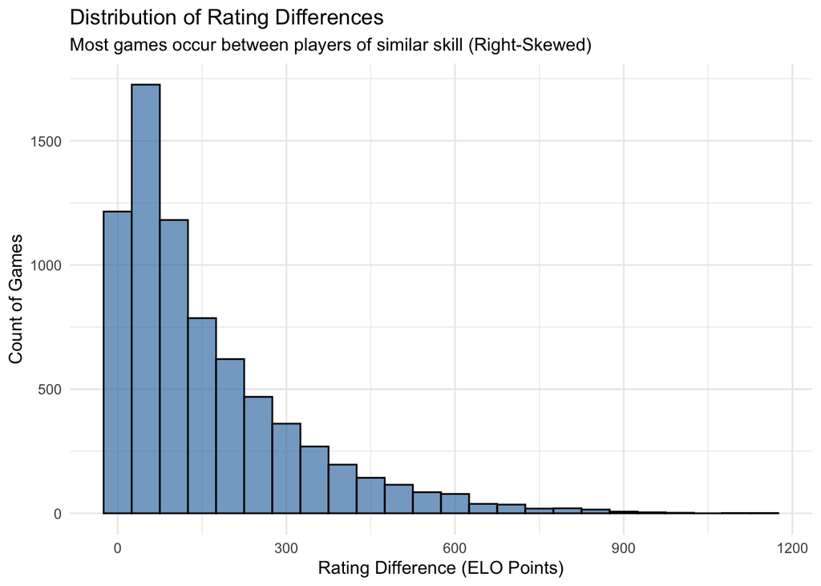

```r
# Distribution plot
ggplot(model_data, aes(x = rating_diff)) +
  geom_histogram(binwidth = 50, fill = "steelblue", color = "black", alpha = 0.7) +
  labs(
    title = "Distribution of Rating Differences",
    subtitle = "Most games occur between players of similar skill (Right-Skewed)",
    x = "Rating Difference (ELO Points)",
    y = "Count of Games"
  ) +
  theme_minimal()
```

**Interpretation**: The distribution is strongly right-skewed. Most matchmaking occurs between players with a rating difference of less than 200 points. This means our model will be most robust in this range, while predictions for extreme rating differences (e.g., >600) rely on fewer data points.

Next, we visualize the relationship between rating difference and win rate:

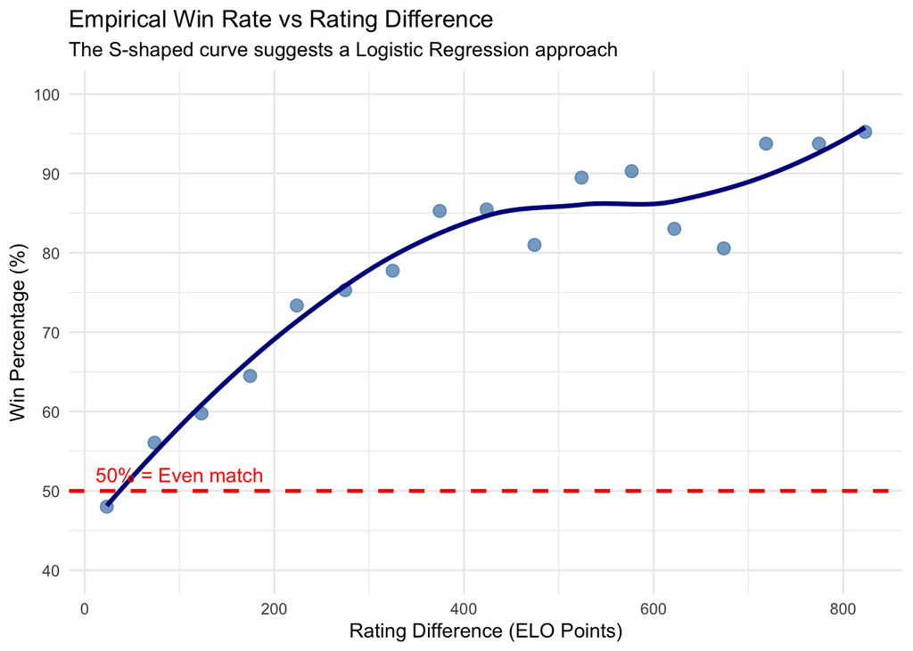

```r
# Calculate win rates by rating difference bins
win_rate_summary <- model_data %>%
  mutate(rating_bin = cut(rating_diff,
                          breaks = seq(0, max(rating_diff) + 50, by = 50),
                          include.lowest = TRUE)) %>%
  group_by(rating_bin) %>%
  summarise(
    rating_diff_mid = mean(rating_diff),
    win_percentage = mean(favorite_won) * 100,
    n = n()
  ) %>%
  filter(n >= 10)  # Only bins with sufficient data

# Visualization with Smooth Curve
ggplot(win_rate_summary, aes(x = rating_diff_mid, y = win_percentage)) +
  geom_point(size = 3, color = "steelblue", alpha = 0.7) +
  geom_smooth(method = "loess", se = FALSE, color = "darkblue", linewidth = 1.2) +
  geom_hline(yintercept = 50, linetype = "dashed", color = "red", linewidth = 1) +
  annotate("text", x = 100, y = 52, label = "50% = Even match", color = "red") +
  labs(
    title = "Empirical Win Rate vs Rating Difference",
    subtitle = "The S-shaped curve suggests a Logistic Regression approach",
    x = "Rating Difference (ELO Points)",
    y = "Win Percentage (%)"
  ) +
  scale_y_continuous(limits = c(40, 100), breaks = seq(40, 100, by = 10)) +
  theme_minimal()
```

### Descriptive Findings:

Baseline: When the rating difference is near 0, the win rate is approximately 50%, indicating a fair match.

Trend: The win rate increases steadily as the rating difference grows.

### Logistic Regression Model Results

We now fit the Generalized Linear Model (GLM).

```r
# Fit Logistic Regression
logit_model <- glm(favorite_won ~ rating_diff,
                   data = model_data,
                   family = binomial(link = "logit"))

# Extract summary
tidy_results <- broom::tidy(logit_model)
kable(tidy_results, caption = "Logistic Regression Model Coefficients")
```

Logistic Regression Model Coefficients

| term | estimate | std.error | statistic | p.value |
| --- | --- | --- | --- | --- |
| (Intercept) | -0.1117432 | 0.0356531 | -3.134183 | 0.0017233 |
| rating_diff | 0.0041850 | 0.0002035 | 20.562924 | 0.0000000 |

### Interpretation and Conclusion

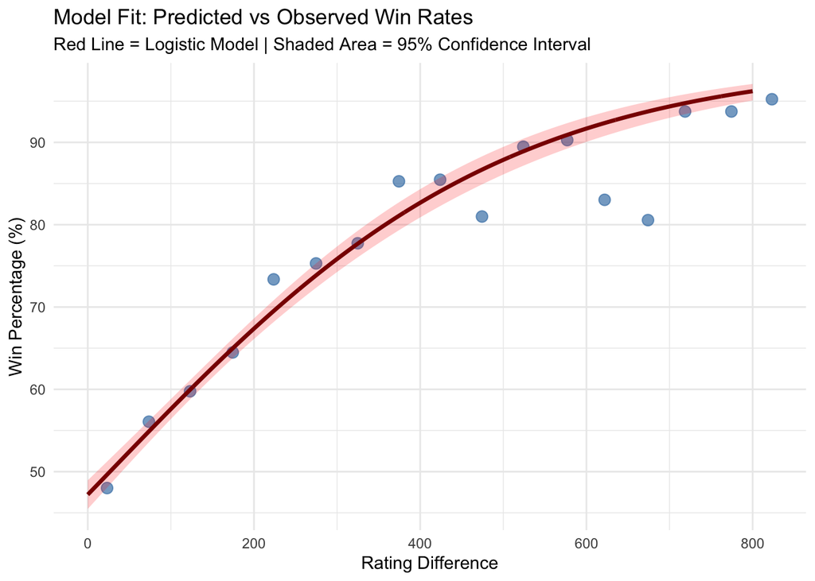

```r
# Generate predictions for a smooth curve
grid_data <- data.frame(rating_diff = seq(0, 800, 1))

# Predict returns probabilities (0-1). We calculate Standard Error to show confidence.
preds <- predict(logit_model, newdata = grid_data, type = "link", se.fit = TRUE)

# Convert from Log-Odds back to Probability
grid_data$predicted_prob <- plogis(preds$fit) * 100
grid_data$lower_ci <- plogis(preds$fit - 1.96 * preds$se.fit) * 100
grid_data$upper_ci <- plogis(preds$fit + 1.96 * preds$se.fit) * 100

ggplot() +
  # Actual data points
  geom_point(data = win_rate_summary, aes(x = rating_diff_mid, y = win_percentage),
             color = "steelblue", size = 3, alpha = 0.7) +
  # Confidence Interval Ribbon (New Addition)
  geom_ribbon(data = grid_data, aes(x = rating_diff, ymin = lower_ci, ymax = upper_ci),
              fill = "red", alpha = 0.2) +
  # Model prediction curve
  geom_line(data = grid_data, aes(x = rating_diff, y = predicted_prob),
            color = "darkred", linewidth = 1.2) +
  labs(
    title = "Model Fit: Predicted vs Observed Win Rates",
    subtitle = "Red Line = Logistic Model | Shaded Area = 95% Confidence Interval",
    x = "Rating Difference",
    y = "Win Percentage (%)"
  ) +
  theme_minimal()
```

Also we can see that our empirical winrate converges to logarithmic curve pretty closely. But there is the one spot where empirical winrate diverges from logarithmic curve – the interval where rating difference is above 600. We see that residuals are negative and significally larger than any other interval’s. Explanation of this phenomenon: very small sample with games more than 600 rating difference compared to those with less than 600.

# General Conclusion

### 1. Opening Choice Affects Game Length

First, we wanted to know if different openings lead to shorter or longer games. Since our data was not normally distributed (right-skewed), we chose the **Kruskal-Wallis test** instead of a standard ANOVA.

### 2. Rating Differences Predict Winners

Second, we tested if the rating gap accurately predicts who wins. We used **Logistic Regression** because the outcome is binary (Win/Loss).

- **Result:** We rejected the Null Hypothesis. The rating gap is a powerful predictor of the match result ($p < 2e^{-16}$).
- **Specific Finding:** The win probability follows a clear “S-curve.” A bigger rating gap leads to a strictly higher chance of winning. However, we noticed that for extreme gaps (over 600 points), our empirical data diverged slightly from the model’s predictions, likely due to the small sample size in that specific range.

### Final Thought

Overall, our analysis confirmed that chess isn’t just random. By using methods like Kruskal-Wallis and Logistic Regression, we proved that both the opening you choose and the rating gap you have are statistically significant drivers of how a game will end.